# Climate Exploration - Ann Arbor, MI

Kiera Matiska

2023-04-12

## Read in Data

```r
climate_clean <- read_csv(here("data", "A2_climate_data.csv")) %>%
  clean_names()

climate <- climate_clean %>%
  mutate(date = ymd(date)) %>%
  mutate(year = substr(date, 1, 4)) %>%
  mutate(month = substr(date, 6, 7)) %>%
  mutate(day = substr(date, 9, 10)) %>%
  mutate(season = case_when(
    month == "01" ~ "winter",
    month == "02" ~ "winter",
    month == "03" ~ "winter",
    month == "04" ~ "spring",
    month == "05" ~ "spring",
    month == "06" ~ "spring",
    month == "07" ~ "summer",
    month == "08" ~ "summer",
    month == "09" ~ "summer",
    month == "10" ~ "fall",
    month == "11" ~ "fall",
    month == "12" ~ "fall"
  ))
```

# Exploration Plots

## Precipitation

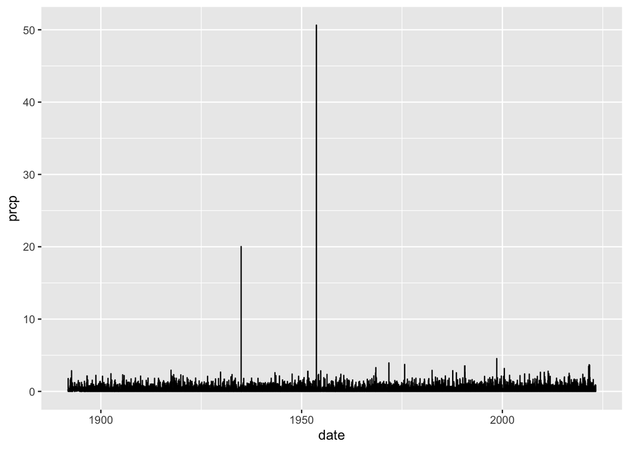

```r
ggplot(climate,
       aes(x = date, y = prcp)) +
  geom_line()
```

## Snow

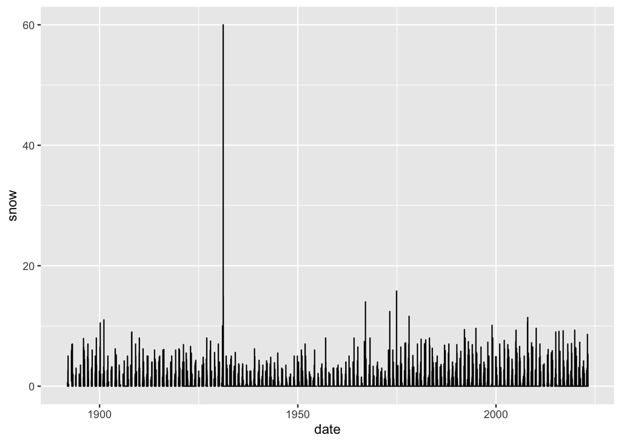

```r
ggplot(climate,
       aes(x = date, y = snow)) +
  geom_line()
```

## Maximum Temperature

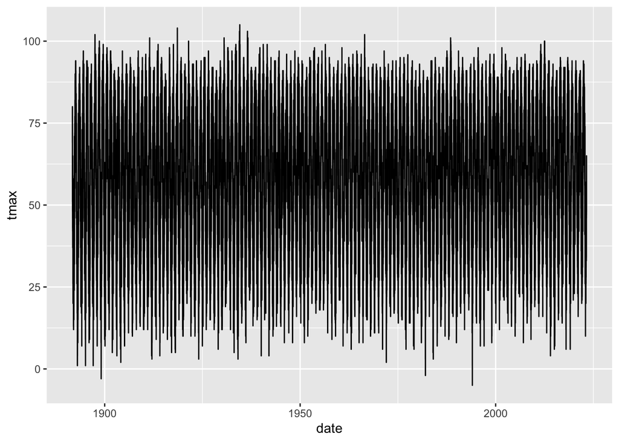

```r
ggplot(climate,
       aes(x = date, y = tmax)) +
  geom_line()
```

## Minimum Temperature

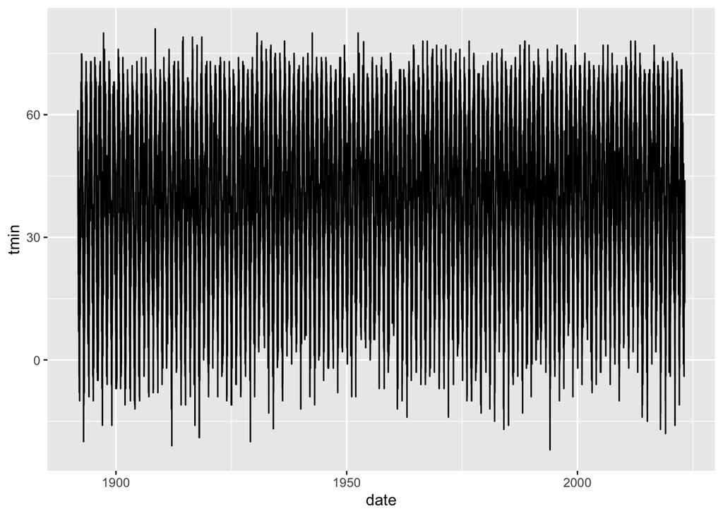

```r
ggplot(climate,
       aes(x = date, y = tmin)) +
  geom_line()
```

# Yearly Trends

## Precipitation (Snow and Rain)

### Over Total Time Period

#### Linear Model

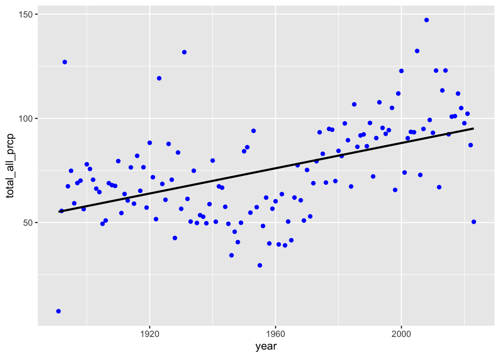

```r
# ggplot(climate_prcp_year_sum,
#        aes(x = year, y = total_all_prcp)) +
#   geom_point(color = "blue") +
#   geom_smooth(formula = y ~ x,
#               color = "black",
#               method = "lm",
#               se = FALSE)

# trend line slope
precip_lm <- lm(total_all_prcp ~ year, data = climate_prcp_year_sum)
precip_confint <- confint(precip_lm, "year", level = 0.95)

ggplot(data = climate_prcp_year_sum,
       aes(x = year, y = total_all_prcp)) +
  stat_summary(fun = "mean",
               geom = "point",
               color = "blue") +
  geom_smooth(method = "lm",
              color = "black",
              se = FALSE)
```

The y-intercept value stands at -517.86 inches. The slope for precipitation by year is 0.303 and is statistically significant with a p-value of 2.09e-09.

#### Mann-Kendall

```r
prcp_mk <- MannKendall(climate_prcp_year_sum$total_all_prcp)
```

The strength of the trend is 0.343 and is statistically significant with a p-value of 2.22e-16.

### Between Time Periods

#### Rank-Sum Test

```r
prcp_91_58_rs <- wilcox.test(subset(climate_prcp_year_sum$total_all_prcp, climate_prcp_year_sum$year %in% 1891:1924),
                             subset(climate_prcp_year_sum$total_all_prcp, climate_prcp_year_sum$year %in% 1925:1958))

prcp_59_23_rs <- wilcox.test(subset(climate_prcp_year_sum$total_all_prcp, climate_prcp_year_sum$year %in% 1959:1992),
                             subset(climate_prcp_year_sum$total_all_prcp, climate_prcp_year_sum$year %in% 1993:2023))

prcp_91_23_rs <- wilcox.test(subset(climate_prcp_year_sum$total_all_prcp, climate_prcp_year_sum$year %in% 1891:1924),
                             subset(climate_prcp_year_sum$total_all_prcp, climate_prcp_year_sum$year %in% 1993:2023))
```

Comparing the years 1891-1924 *and* 1925-1958, the rank-sum test did yield statistically significant differences in the means with a p-value of 0.023.

Comparing the years 1959-1992 *and* 1993-2023, the rank-sum test did yield statistically significant differences in the means with a p-value of 1.72e-06.

Comparing the years 1891-1924 *and* 1993-2023, the rank-sum test did yield statistically significant differences in the means with a p-value of 4.13e-08.

## Temperature

### Overall Time Period

#### Linear Model

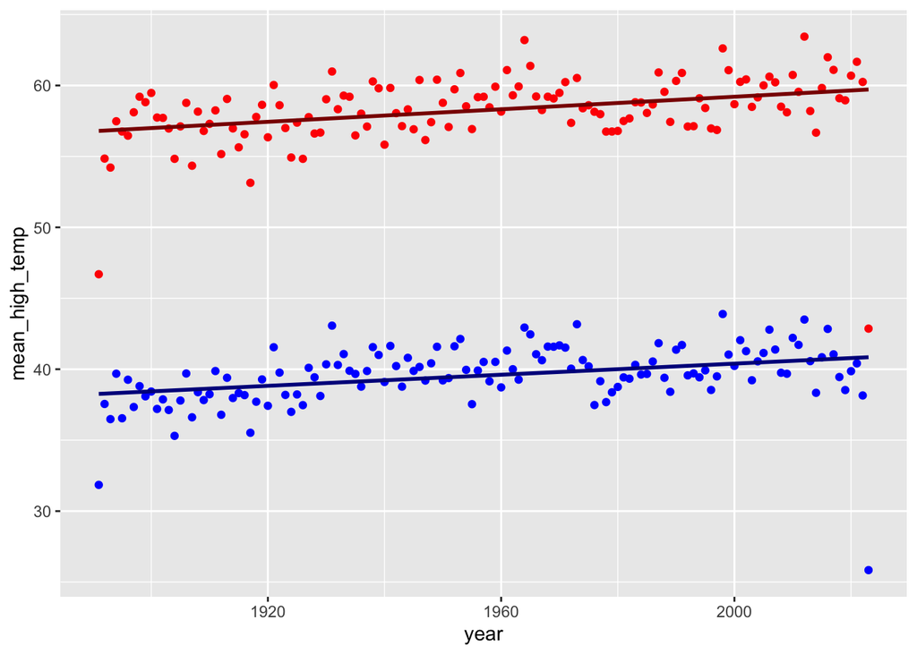

```r
# graph plotting the average high and low temperatures each year with trend lines
# ggplot(climate_temp_year_sum) +
#   geom_point(aes(x = year, y = mean_high_temp),
#              color = "red") +
#   geom_smooth(aes(x = year, y = mean_high_temp),
#               formula = y ~ x,
#               color = "black",
#               method = "lm",
#               se = FALSE) +
#   geom_point(aes(x = year, y = mean_low_temp),
#              color = "blue") +
#   geom_smooth(aes(x = year, y = mean_low_temp),
#               formula = y ~ x,
#               color = "black",
#               method = "lm",
#               se = FALSE)

# trend line slopes
t_high_lm <- lm(mean_high_temp ~ year, data = climate_temp_year_sum)
t_high_confint <- confint(t_high_lm, "year", level = 0.95)

t_low_lm <- lm(mean_low_temp ~ year, data = climate_temp_year_sum)
t_low_confint <- confint(t_low_lm, "year", level = 0.95)

ggplot(data = climate_temp_year_sum) +
  stat_summary(aes(x = year, y = mean_high_temp),
               fun = "mean",
               geom = "point",
               color = "red") +
  stat_summary(aes(x = year, y = mean_low_temp),
               fun = "mean",
               geom = "point",
               color = "blue") +
  geom_smooth(aes(x = year, y = mean_high_temp),
              method = "lm",
              color = "darkred",
              se = FALSE) +
  geom_smooth(aes(x = year, y = mean_low_temp),
              method = "lm",
              color = "darkblue",
              se = FALSE)
```

For average high temperatures, the y-intercept is 15.02. The slope for average high temperature per year is 0.02 and is statistically significant with a p-value of 5.78e-05.

For average low temperatures, they y-intercept is 1.24. The slope for average low temperature per year is 0.02 and is statistically significant with a p-value of 4.28e-05.

#### Mann-Kendall

```r
# Mann Kendall method for average high temperature
temp_high_mk <- MannKendall(climate_temp_year_sum$mean_high_temp)

# Mann Kendall method for average low temperature
temp_low_mk <- MannKendall(climate_temp_year_sum$mean_low_temp)
```

For average high temperatures, the strength of the trend is 0.32 and is statistically significant with a p-value of 2.22e-16.

For average low temperatures, the strength of the trend is 0.34 and is statistically significant with a p-value of 2.22e-16.

### Between Time Periods

#### Rank-Sum Test

```r
# Average High Temperature Rank-Sum Test
t_high_91_58_rs <- wilcox.test(subset(climate_temp_year_sum$mean_high_temp, climate_temp_year_sum$year %in% 1891:1924),
                               subset(climate_temp_year_sum$mean_high_temp, climate_temp_year_sum$year %in% 1925:1958))

t_high_59_23_rs <- wilcox.test(subset(climate_temp_year_sum$mean_high_temp, climate_temp_year_sum$year %in% 1959:1992),
                               subset(climate_temp_year_sum$mean_high_temp, climate_temp_year_sum$year %in% 1993:2023))

t_high_91_23_rs <- wilcox.test(subset(climate_temp_year_sum$mean_high_temp, climate_temp_year_sum$year %in% 1891:1924),
                               subset(climate_temp_year_sum$mean_high_temp, climate_temp_year_sum$year %in% 1993:2023))

# Average Low Temperature Rank-Sum Test
t_low_91_58_rs <- wilcox.test(subset(climate_temp_year_sum$mean_low_temp, climate_temp_year_sum$year %in% 1891:1924),
                              subset(climate_temp_year_sum$mean_low_temp, climate_temp_year_sum$year %in% 1925:1958))

t_low_59_23_rs <- wilcox.test(subset(climate_temp_year_sum$mean_low_temp, climate_temp_year_sum$year %in% 1959:1992),
                              subset(climate_temp_year_sum$mean_low_temp, climate_temp_year_sum$year %in% 1993:2023))

t_low_91_23_rs <- wilcox.test(subset(climate_temp_year_sum$mean_low_temp, climate_temp_year_sum$year %in% 1891:1924),
                              subset(climate_temp_year_sum$mean_low_temp, climate_temp_year_sum$year %in% 1993:2023))
```

For average high temperatures:

- Comparing the years 1891-1924 *and* 1925-1958, the rank-sum test did yield statistically significant differences in the means with a p-value of 0.0058.
- Comparing the years 1959-1992 *and* 1993-2023, the rank-sum test did not yield statistically significant differences in the means with a p-value of 0.18.
- Comparing the years 1891-1924 *and* 1993-2023, the rank-sum test did yield statistically significant differences in the means with a p-value of 1.36e-06.

For average low temperatures:

- Comparing the years 1891-1924 *and* 1925-1958, the rank-sum test did yield statistically significant differences in the means with a p-value of 2.44e-08.
- Comparing the years 1959-1992 *and* 1993-2023, the rank-sum test did not yield statistically significant differences in the means with a p-value of 0.69.
- Comparing the years 1891-1924 *and* 1993-2023, the rank-sum test did yield statistically significant differences in the means with a p-value of 1.26e-08.

# Seasonal Trends

## Precipitation (Rain and Snow)

### Summer

#### Overall Time Period

##### Linear Model

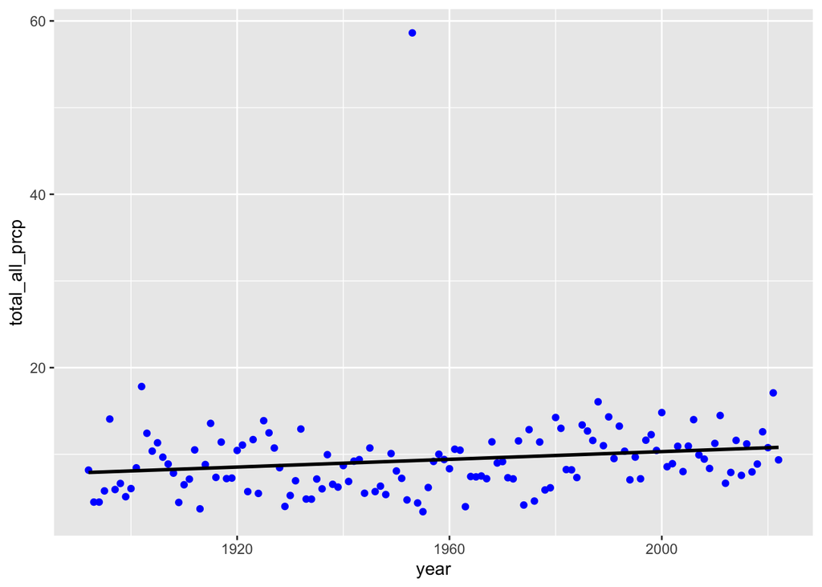

```r
# ggplot(clim_prcp_summer,
#        aes(x = year, y = total_all_prcp)) +
#   geom_point(color = "blue") +
#   geom_smooth(formula = y ~ x,
#               color = "black",
#               method = "lm",
#               se = FALSE)

# trend line slope
prcp_summer_lm <- lm(total_all_prcp ~ year, data = clim_prcp_summer)
prcp_summer_confint <- confint(prcp_summer_lm, "year", level = 0.95)

ggplot(data = clim_prcp_summer,
       aes(x = year, y = total_all_prcp)) +
  stat_summary(fun = "mean",
               geom = "point",
               color = "blue") +
  geom_smooth(method = "lm",
              color = "black",
              se = FALSE)
```

For yearly total summer precipitation, the y-intercept is -34.26. The slope of total summer precipitation by year is 0.022 and is not statistically significant (p-value = 0.069).

##### Mann-Kendall

```r
prcp_summer_mk <- MannKendall(clim_prcp_summer$total_all_prcp)
```

For yearly total summer precipitation, the strength is 0.206 and is statistically significant with a p-value of 0.00048.

#### Between Time Periods

##### Rank-Sum Test

```r
prcp_summer_91_58_rs <- wilcox.test(subset(clim_prcp_summer$total_all_prcp, clim_prcp_summer$year %in% 1891:1924),
                                    subset(clim_prcp_summer$total_all_prcp, clim_prcp_summer$year %in% 1925:1958))

prcp_summer_59_23_rs <- wilcox.test(subset(clim_prcp_summer$total_all_prcp, clim_prcp_summer$year %in% 1959:1992),
                                    subset(clim_prcp_summer$total_all_prcp, clim_prcp_summer$year %in% 1993:2023))

prcp_summer_91_23_rs <- wilcox.test(subset(clim_prcp_summer$total_all_prcp, clim_prcp_summer$year %in% 1891:1924),
                                    subset(clim_prcp_summer$total_all_prcp, clim_prcp_summer$year %in% 1993:2023))
```

Comparing the years 1891-1924 *and* 1925-1958, the rank-sum test did not yield statistically significant differences in the means with a p-value of 0.42.

Comparing the years 1959-1992 *and* 1993-2023, the rank-sum test did not yield statistically significant differences in the means with a p-value of 0.37.

Comparing the years 1891-1924 *and* 1993-2023, the rank-sum test did yield statistically significant differences in the means with a p-value of 0.01.

### Winter

#### Overall Time Period

##### Linear Model

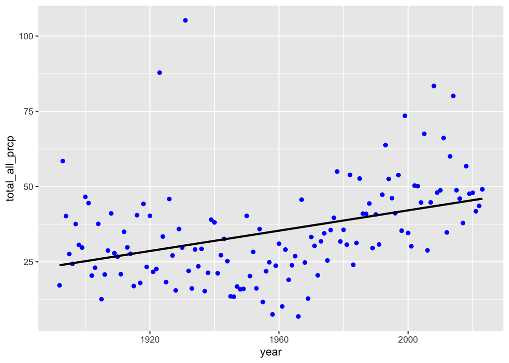

```r
# ggplot(clim_prcp_winter,
#        aes(x = year, y = total_all_prcp)) +
#   geom_point(color = "blue") +
#   geom_smooth(formula = y ~ x,
#               color = "black",
#               method = "lm",
#               se = FALSE)

# trend line slope
prcp_winter_lm <- lm(total_all_prcp ~ year, data = clim_prcp_winter)
prcp_winter_confint <- confint(prcp_winter_lm, "year", level = 0.95)

ggplot(data = clim_prcp_winter,
       aes(x = year, y = total_all_prcp)) +
  stat_summary(fun = "mean",
               geom = "point",
               color = "blue") +
  geom_smooth(method = "lm",
              color = "black",
              se = FALSE)
```

For yearly total winter precipitation, the y-intercept is -295.62. The slope for yearly winter precipitation by year is 0.17 and is statistically significant with a p-value of 3.87e-06.

##### Mann-Kendall

```r
prcp_winter_mk <- MannKendall(clim_prcp_winter$total_all_prcp)
```

The strength of the trend is 0.311 and is statistically significant with a p-value of 1.19e-07.

#### Between Time Periods

##### Rank-Sum Test

```r
prcp_winter_91_58_rs <- wilcox.test(subset(clim_prcp_winter$total_all_prcp, clim_prcp_winter$year %in% 1891:1924),
                                    subset(clim_prcp_winter$total_all_prcp, clim_prcp_winter$year %in% 1925:1958))

prcp_winter_59_23_rs <- wilcox.test(subset(clim_prcp_winter$total_all_prcp, clim_prcp_winter$year %in% 1959:1992),
                                    subset(clim_prcp_winter$total_all_prcp, clim_prcp_winter$year %in% 1993:2023))

prcp_winter_91_23_rs <- wilcox.test(subset(clim_prcp_winter$total_all_prcp, clim_prcp_winter$year %in% 1891:1924),
                                    subset(clim_prcp_winter$total_all_prcp, clim_prcp_winter$year %in% 1993:2023))
```

Comparing the years 1891-1924 *and* 1925-1958, the rank-sum test did yield statistically significant differences in the means with a p-value of 0.019.

Comparing the years 1959-1992 *and* 1993-2023, the rank-sum test did yield statistically significant differences in the means with a p-value of 2.16e-07.

Comparing the years 1891-1924 *and* 1993-2023, the rank-sum test did yield statistically significant differences in the means with a p-value of 3.89e-08.

## Temperature

### Summer

#### Overall Time Period

##### Linear Model

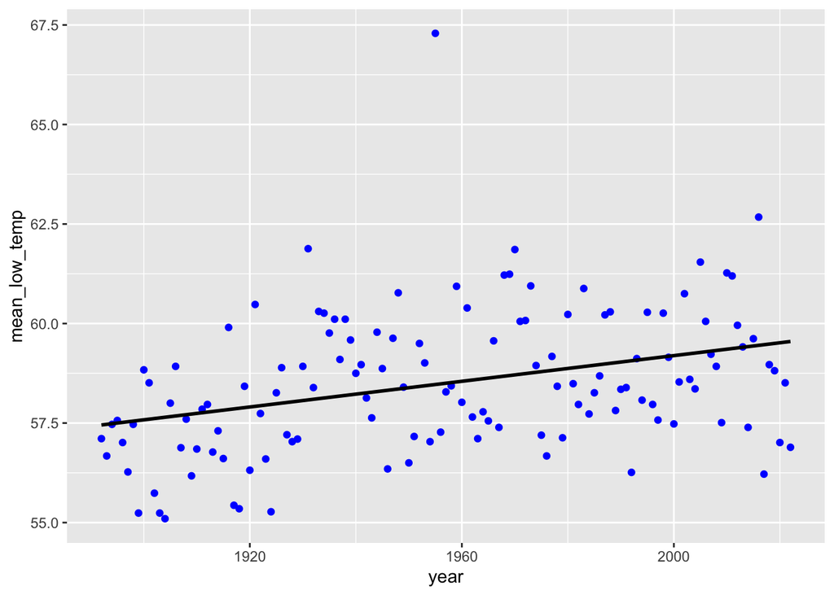

```r
# graph plotting the average high and low temperatures each year with trend lines
# ggplot(clim_temp_summer) +
#   geom_point(aes(x = year, y = mean_high_temp),
#              color = "red") +
#   geom_smooth(aes(x = year, y = mean_high_temp),
#               formula = y ~ x,
#               color = "black",
#               method = "lm",
#               se = FALSE) +
#   geom_point(aes(x = year, y = mean_low_temp),
#              color = "blue") +
#   geom_smooth(aes(x = year, y = mean_low_temp),
#               formula = y ~ x,
#               color = "black",
#               method = "lm",
#               se = FALSE)

# trend line slopes
t_high_summer_lm <- lm(mean_high_temp ~ year, data = clim_temp_summer)
t_high_summer_confint <- confint(t_high_summer_lm, "year", level = 0.95)

t_low_summer_lm <- lm(mean_low_temp ~ year, data = clim_temp_summer)
t_low_summer_confint <- confint(t_low_summer_lm, "year", level = 0.95)

ggplot(data = clim_temp_summer,
       aes(x = year, y = mean_low_temp)) +
  stat_summary(fun = "mean",
               geom = "point",
               color = "blue") +
  geom_smooth(method = "lm",
              color = "black",
              se = FALSE)
```

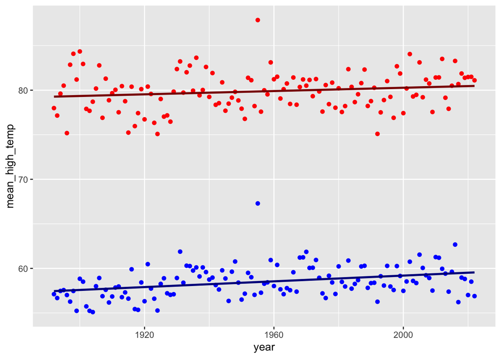

```r
ggplot(data = clim_temp_summer) +
  stat_summary(aes(x = year, y = mean_high_temp),
               fun = "mean",
               geom = "point",
               color = "red") +
  stat_summary(aes(x = year, y = mean_low_temp),
               fun = "mean",
               geom = "point",
               color = "blue") +
  geom_smooth(aes(x = year, y = mean_high_temp),
              method = "lm",
              color = "darkred",
              se = FALSE) +
  geom_smooth(aes(x = year, y = mean_low_temp),
              method = "lm",
              color = "darkblue",
              se = FALSE)
```

For yearly summer average high temperatures, the y-intercept is 61.78. The slope for average high temperature per year is 0.009 and is not statistically significant with a p-value of 0.066.

For yearly summer average low temperatures, they y-intercept is 26.94. The slope for average low temperature per year is 0.016 and is statistically significant with a p-value of 6.01e-05.

##### Mann-Kendall

```r
# Mann Kendall method for average high temperature
t_high_summer_mk <- MannKendall(clim_temp_summer$mean_high_temp)

# Mann Kendall method for average low temperature
t_low_summer_mk <- MannKendall(clim_temp_summer$mean_low_temp)
```

For yearly summer average high temperatures, the strength of the trend is 0.12 and is statistically significant with a p-value of 0.04.

For yearly summer average low temperatures, the strength of the trend is 0.25 and is statistically significant with a p-value of 3.52e-05.

#### Between Time Periods

##### Rank-Sum Test

```r
# Average High Temperature Rank-Sum Test
t_high_summer_91_58_rs <- wilcox.test(subset(clim_temp_summer$mean_high_temp, clim_temp_summer$year %in% 1891:1924),
                                      subset(clim_temp_summer$mean_high_temp, clim_temp_summer$year %in% 1925:1958))

t_high_summer_59_23_rs <- wilcox.test(subset(clim_temp_summer$mean_high_temp, clim_temp_summer$year %in% 1959:1992),
                                      subset(clim_temp_summer$mean_high_temp, clim_temp_summer$year %in% 1993:2023))

t_high_summer_91_23_rs <- wilcox.test(subset(clim_temp_summer$mean_high_temp, clim_temp_summer$year %in% 1891:1924),
                                      subset(clim_temp_summer$mean_high_temp, clim_temp_summer$year %in% 1993:2023))

# Average Low Temperature Rank-Sum Test
t_low_summer_91_58_rs <- wilcox.test(subset(clim_temp_summer$mean_low_temp, clim_temp_summer$year %in% 1891:1924),
                                     subset(clim_temp_summer$mean_low_temp, clim_temp_summer$year %in% 1925:1958))

t_low_summer_59_23_rs <- wilcox.test(subset(clim_temp_summer$mean_low_temp, clim_temp_summer$year %in% 1959:1992),
                                     subset(clim_temp_summer$mean_low_temp, clim_temp_summer$year %in% 1993:2023))

t_low_summer_91_23_rs <- wilcox.test(subset(clim_temp_summer$mean_low_temp, clim_temp_summer$year %in% 1891:1924),
                                     subset(clim_temp_summer$mean_low_temp, clim_temp_summer$year %in% 1993:2023))
```

For yearly average summer high temperatures:

- Comparing the years 1891-1924 *and* 1925-1958, the rank-sum test did yield not statistically significant differences in the means with a p-value of 0.36.
- Comparing the years 1959-1992 *and* 1993-2023, the rank-sum test did not yield statistically significant differences in the means with a p-value of 0.16.
- Comparing the years 1891-1924 *and* 1993-2023, the rank-sum test did yield statistically significant differences in the means with a p-value of 0.018.

For yearly average summer low temperatures:

- Comparing the years 1891-1924 *and* 1925-1958, the rank-sum test did yield statistically significant differences in the means with a p-value of 1.6e-05.
- Comparing the years 1959-1992 *and* 1993-2023, the rank-sum test did not yield statistically significant differences in the means with a p-value of 0.7.
- Comparing the years 1891-1924 *and* 1993-2023, the rank-sum test did yield statistically significant differences in the means with a p-value of 4.74e-06.

### Winter

#### Overall Time Period

##### Linear Model

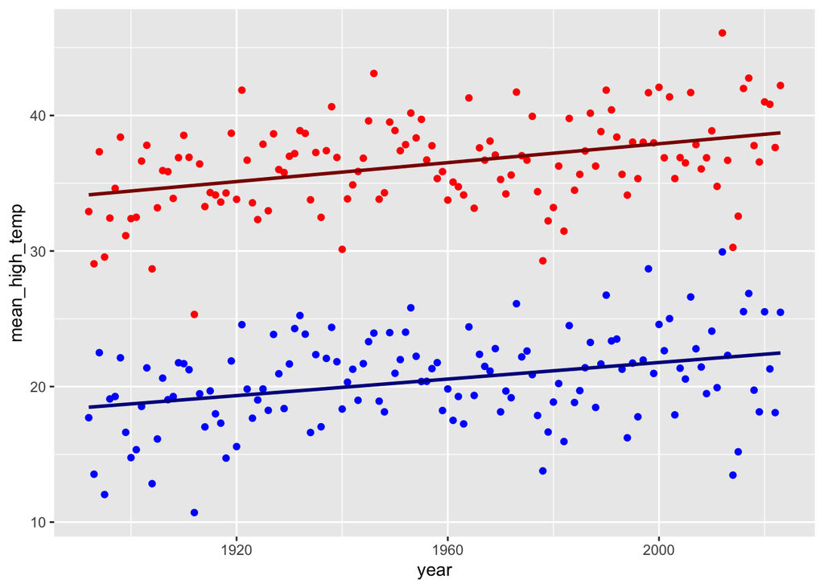

```r
# graph plotting the average high and low temperatures each year with trend lines
# ggplot(clim_temp_winter) +
#   geom_point(aes(x = year, y = mean_high_temp),
#              color = "red") +
#   geom_smooth(aes(x = year, y = mean_high_temp),
#               formula = y ~ x,
#               color = "black",
#               method = "lm",
#               se = FALSE) +
#   geom_point(aes(x = year, y = mean_low_temp),
#              color = "blue") +
#   geom_smooth(aes(x = year, y = mean_low_temp),
#               formula = y ~ x,
#               color = "black",
#               method = "lm",
#               se = FALSE)

# trend line slopes
t_high_winter_lm <- lm(mean_high_temp ~ year, data = clim_temp_winter)
t_high_winter_confint <- confint(t_high_winter_lm, "year", level = 0.95)

t_low_winter_lm <- lm(mean_low_temp ~ year, data = clim_temp_winter)
t_low_winter_confint <- confint(t_low_winter_lm, "year", level = 0.95)

ggplot(data = clim_temp_winter) +
  stat_summary(aes(x = year, y = mean_high_temp),
               fun = "mean",
               geom = "point",
               color = "red") +
  stat_summary(aes(x = year, y = mean_low_temp),
               fun = "mean",
               geom = "point",
               color = "blue") +
  geom_smooth(aes(x = year, y = mean_high_temp),
              method = "lm",
              color = "darkred",
              se = FALSE) +
  geom_smooth(aes(x = year, y = mean_low_temp),
              method = "lm",
              color = "darkblue",
              se = FALSE)
```

For yearly winter average high temperatures, the y-intercept is -31.85. The slope for average high temperature per year is 0.035 and is statistically significant with a p-value of 2.33e-06.

For yearly winter average low temperatures, they y-intercept is -39.29. The slope for average low temperature per year is 0.031 and is statistically significant with a p-value of 5.6e-05.

##### Mann-Kendall

```r
# Mann Kendall method for average high temperature
t_high_winter_mk <- MannKendall(clim_temp_winter$mean_high_temp)

# Mann Kendall method for average low temperature
t_low_winter_mk <- MannKendall(clim_temp_winter$mean_low_temp)
```

For yearly winter average high temperatures, the strength of the trend is 0.26 and is statistically significant with a p-value of 1.19e-05.

For yearly winter average low temperatures, the strength of the trend is 0.21 and is statistically significant with a p-value of 0.00029.

#### Between Time Periods

##### Rank-Sum Test

```r
# Average High Temperature Rank-Sum Test
t_high_winter_91_58_rs <- wilcox.test(subset(clim_temp_winter$mean_high_temp, clim_temp_winter$year %in% 1891:1924),
                                      subset(clim_temp_winter$mean_high_temp, clim_temp_winter$year %in% 1925:1958))

t_high_winter_59_23_rs <- wilcox.test(subset(clim_temp_winter$mean_high_temp, clim_temp_winter$year %in% 1959:1992),
                                      subset(clim_temp_winter$mean_high_temp, clim_temp_winter$year %in% 1993:2023))

t_high_winter_91_23_rs <- wilcox.test(subset(clim_temp_winter$mean_high_temp, clim_temp_winter$year %in% 1891:1924),
                                      subset(clim_temp_winter$mean_high_temp, clim_temp_winter$year %in% 1993:2023))

# Average Low Temperature Rank-Sum Test
t_low_winter_91_58_rs <- wilcox.test(subset(clim_temp_winter$mean_low_temp, clim_temp_winter$year %in% 1891:1924),
                                     subset(clim_temp_winter$mean_low_temp, clim_temp_winter$year %in% 1925:1958))

t_low_winter_59_23_rs <- wilcox.test(subset(clim_temp_winter$mean_low_temp, clim_temp_winter$year %in% 1959:1992),
                                     subset(clim_temp_winter$mean_low_temp, clim_temp_winter$year %in% 1993:2023))

t_low_winter_91_23_rs <- wilcox.test(subset(clim_temp_winter$mean_low_temp, clim_temp_winter$year %in% 1891:1924),
                                     subset(clim_temp_winter$mean_low_temp, clim_temp_winter$year %in% 1993:2023))
```

For yearly average winter high temperatures:

- Comparing the years 1891-1924 *and* 1925-1958, the rank-sum test did yield statistically significant differences in the means with a p-value of 0.00063.
- Comparing the years 1959-1992 *and* 1993-2023, the rank-sum test did yield statistically significant differences in the means with a p-value of 0.032.
- Comparing the years 1891-1924 *and* 1993-2023, the rank-sum test did yield statistically significant differences in the means with a p-value of 7.83e-05.

For yearly average winter low temperatures:

- Comparing the years 1891-1924 *and* 1925-1958, the rank-sum test did yield statistically significant differences in the means with a p-value of 7.91e-05.
- Comparing the years 1959-1992 *and* 1993-2023, the rank-sum test did not yield statistically significant differences in the means with a p-value of 0.14.
- Comparing the years 1891-1924 *and* 1993-2023, the rank-sum test did yield statistically significant differences in the means with a p-value of 0.00021.

# Data Citation

NOAA. (2023). Daily Summaries at the Ann Arbor University of Michigan Station. NOAA. https://www.ncei.noaa.gov/cdo-web/datasets/GHCND/stations/GHCND:USC00200230/detail